# SAIL Application - Conferences based on Offensive Performance

# K-mean Clustering

| CONF | MEANO | MEAND | SDO | SDD |
| --- | --- | --- | --- | --- |
| A10 | 104.25714 | 98.48571 | 6.314539 | 4.456777 |
| ACC | 109.54000 | 96.79333 | 4.936714 | 3.546319 |
| AE | 96.64000 | 103.85000 | 5.148074 | 3.598534 |
| Amer | 104.57273 | 96.50000 | 6.400639 | 4.300698 |
| ASun | 98.64444 | 106.30000 | 6.866606 | 3.276431 |
| B10 | 111.41429 | 93.51429 | 6.698548 | 2.086166 |
| B12 | 109.65000 | 95.02000 | 7.489140 | 3.432136 |
| BE | 109.24545 | 95.41818 | 5.424456 | 1.825825 |
| BSky | 99.17273 | 105.60000 | 5.779116 | 4.510654 |
| BSth | 97.93636 | 105.77273 | 4.546267 | 3.491731 |
| BW | 99.97273 | 103.68182 | 4.425176 | 5.711886 |
| CAA | 100.99000 | 104.69000 | 4.252176 | 4.401629 |
| CUSA | 101.15714 | 100.65714 | 4.869957 | 4.524755 |
| Horz | 101.14167 | 106.69167 | 4.220181 | 4.141247 |
| MAAC | 96.24545 | 103.19091 | 3.874110 | 4.615291 |
| MAC | 103.58333 | 103.55000 | 5.836536 | 4.363797 |
| MEAC | 93.13333 | 107.83333 | 4.472974 | 5.697807 |
| MVC | 103.00000 | 100.70000 | 4.835746 | 5.478240 |
| MWC | 103.37273 | 100.71818 | 5.849289 | 6.941155 |
| NEC | 97.85000 | 106.64000 | 3.978903 | 4.725627 |
| OVC | 98.74167 | 105.24167 | 5.667364 | 4.180574 |
| P12 | 108.25833 | 97.20833 | 4.909630 | 3.348123 |
| Pat | 100.62000 | 105.05000 | 4.743604 | 3.823974 |
| SB | 98.43333 | 104.07500 | 3.639014 | 2.123087 |
| SC | 103.08000 | 103.09000 | 3.356850 | 3.542896 |
| SEC | 108.89286 | 95.17143 | 4.130275 | 4.237820 |
| Slnd | 96.25385 | 107.60769 | 4.019870 | 5.602300 |
| Sum | 100.10000 | 106.56667 | 6.051446 | 3.629738 |
| SWAC | 89.71000 | 107.27000 | 4.998767 | 7.140191 |
| WAC | 97.42222 | 104.90000 | 6.951579 | 5.893428 |
| WCC | 105.57000 | 97.87000 | 8.499026 | 6.474403 |

As indicated by the chart above, some conferences perform better offensively or defensively. Generally, conferences are created based on the location of the school, not the performance of the team. If conferences were to be assigned based on their offensive or defensive efficiency, it may create an environment for college basketball that facilitates increased innovation in the sport. The benefit of grouping the teams based on their offensive quality instead of geographical-based conferences is questioned. In order to create a portfolio of conferences, I selected the number of wins, offensive efficiency metric, turnover over rate, and effective field goal percentage (shot). These variables act as quantitative representations of how the teams perform offensively, as that is the primary factor in determining a successful team. In order to create new conferences, a k-means clustering method is used. K-means clustering partitions the teams into a fixed number of clusters, k, based on their distance to the cluster’s mean, the centroid, which is calculated using the factors provides. In the case of the new conferences, the factors will be the offense variables.

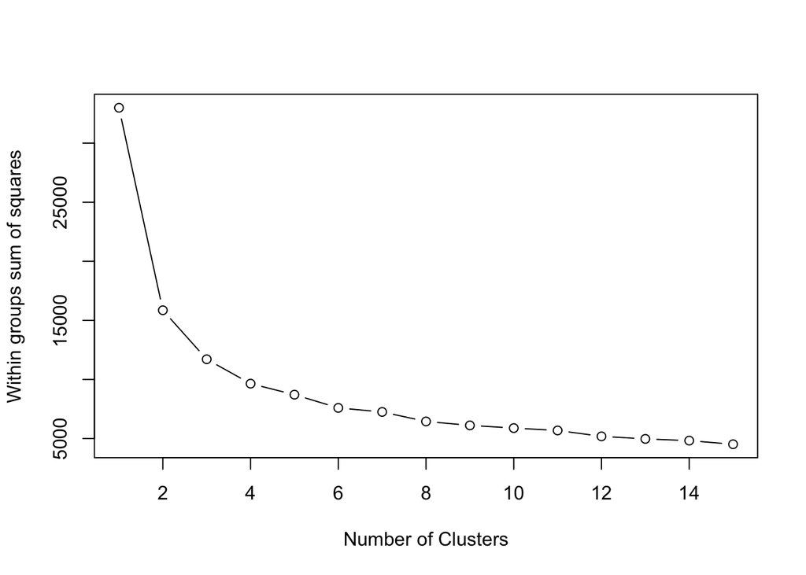

Although using the elbow method in k-means clustering is usual for finding “optimal” k, in the real world it has little use. We would choose the number of conferences based on the need of the teams, advertisers, and other stakeholders in the sports world; however, without that information, the number will be chosen using the elbow method, and there is a possible elbow at k = 6.

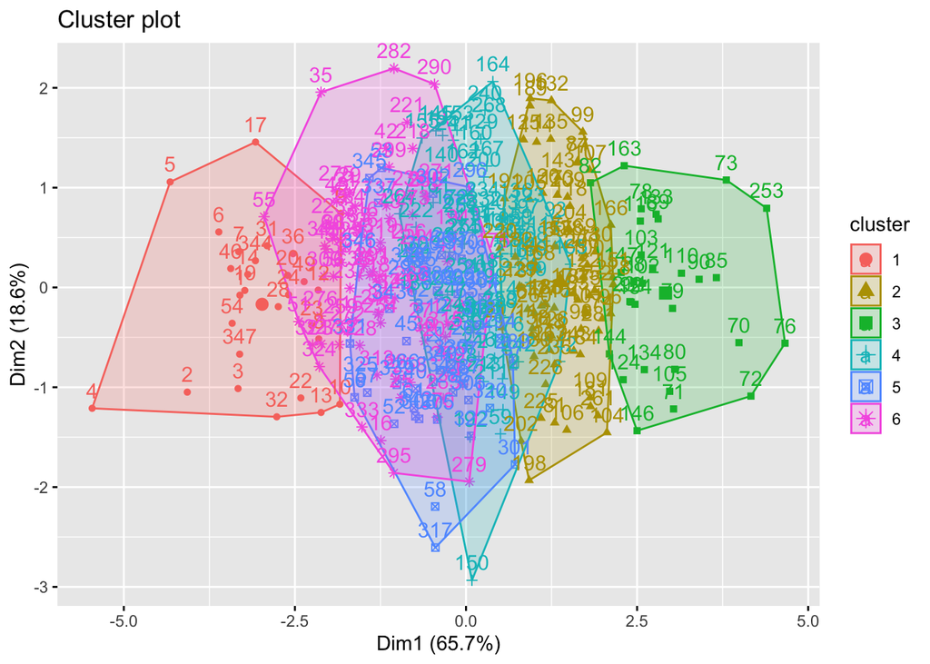

The plot above is a visualization of the new conferences created. Graphically, it is clear that many teams overlap with each other in performance, as generally teams are not vastly different.

| cluster_group | W | ADJOE | TOR | EFG_O | ADJDE |
| --- | --- | --- | --- | --- | --- |
| 1 | 21.178571 | 115.01786 | 16.73571 | 54.14643 | 94.65714 |
| 2 | 8.040000 | 95.47733 | 20.00667 | 48.16800 | 105.32800 |
| 3 | 4.933333 | 89.87000 | 21.87000 | 45.26000 | 107.60667 |
| 4 | 9.518987 | 101.37468 | 18.64304 | 49.88101 | 104.07975 |
| 5 | 16.709091 | 101.65455 | 19.42364 | 50.72909 | 99.99091 |
| 6 | 14.625000 | 108.62375 | 17.71625 | 51.63500 | 98.41875 |

| CONF_1 | CONF_2 | CONF_3 | CONF_4 | CONF_5 | CONF_6 |
| --- | --- | --- | --- | --- | --- |
| Michigan | Mount St. Mary’s | South Carolina St. | Iona | VCU | Kansas |
| Baylor | Howard | Idaho | Boston College | Utah St. | Purdue |
| Illinois | Denver | Maine | Bucknell | Winthrop | Oklahoma St. |
| Gonzaga | Iowa St. | Fordham | Temple | North Texas | Tennessee |
| Iowa | San Diego | Mississippi Valley St. | Holy Cross | UNC Greensboro | Texas Tech |
| Ohio St. | American | Northern Illinois | George Washington | Abilene Christian | Florida |

This is a brief glimpse of what the newly formed conferences would look like. As you can see, they are no longer grouped by factors such as region, but rather by their offensive status. The mission of this analysis was to critically examine how offense and defense are used in college basketball, and how teams can enhance their performance by balancing both sides. The new conferences would be an incentive for the teams to innovate their playing strategy and would improve the watching experience of fans by creating suspense with more closely matched teams.